# A la recerca de l’Ohio de Barcelona

Quin barri i quina secció censal voten més com el conjunt de la ciutat?

Autor/a

Jordi Muñoz

Publicat

30 Setembre 2026

**Mostra el codi**

```css
/* Leaflet legends: the 18px swatches float left, so lines must be 18px high
   or the swatches stair-step; a hairline ring keeps the light grey midpoint
   visible on the white legend box. */
.leaflet .legend {
  line-height: 18px;
  text-align: left;
}
.leaflet .legend i {
  clear: left;
  box-sizing: border-box;
  border: 1px solid rgba(11, 11, 11, 0.25);
}
```

# 1 La idea: buscar el nostre Ohio

Als Estats Units, **Ohio** és l’exemple clàssic d’*estat termòmetre* (*bellwether*): entre 1964 i 2016 va votar sempre pel candidat que acabava guanyant la presidència. Si volies saber qui guanyaria, n’hi havia prou de mirar què passava a Ohio.

La pregunta d’aquest treball és: **Barcelona té el seu Ohio?** És a dir, hi ha algun barri, o algun racó més petit de la ciutat, on la gent vota gairebé exactament com el conjunt de Barcelona? No en el sentit de *qui guanya*, sinó en un sentit més exigent: que el repartiment de vots entre **tots** els partits s’assembli tant com sigui possible al resultat de tota la ciutat.

Ho mirem a dues escales:

- **Barris** (els 73 barris oficials de la ciutat).
- **Seccions censals**, les unitats més petites en què es divideix el cens electoral, d’unes poques desenes d’illes de cases i al voltant d’un miler d’electors cadascuna.

# 2 Les dades

Fem servir els resultats de les **eleccions municipals de Barcelona** publicats per l’Ajuntament al [Portal de Dades de Barcelona](https://portaldades.ajuntament.barcelona.cat/ca/microdades/78d2734c-35ee-49de-86c6-4bafef2e8e05). Per a cada elecció i secció censal hi ha el nombre d’electors, de votants, de vots nuls, de vots en blanc i de vots a cada candidatura.

Les dades tenen tres limitacions que condicionen l’anàlisi:

1. **1979 i 1983** només tenen el total de la ciutat, sense cap desglossament territorial. Per tant, no es poden fer servir.
2. **Els barris** només apareixen a les dades a partir de **2011** (la divisió actual en 73 barris és del 2009). Per a les eleccions de 1987 a 2007 només tenim districte i secció censal. Per a 1999, 2003 i 2007 ho hem pogut resoldre amb mapes (vegeu més avall).
3. **Les seccions censals canvien** amb el temps: se’n divideixen, se’n fusionen i se’n redibuixen. El 1987 n’hi havia 1.917 i des del 2011 n’hi ha unes 1.068. Una mateixa secció (per exemple, «Eixample, secció 9») no correspon necessàriament al mateix territori el 1991 i el 2023.

Per això analitzem **cada elecció per separat** des de 1987 per a les seccions i des de 1999 per als barris. Per a la **classificació global** (tenint en compte diverses eleccions alhora) fem servir totes les eleccions amb barris (1999–2023), però per a les seccions ens limitem a **2011–2023**, l’únic període en què són comparables.

# 3 Com ho hem fet

## 3.1 Cada lloc, un vector de percentatges

Per a cada elecció, calculem el percentatge de vot de cada opció sobre els **vots vàlids** (candidatures més vots en blanc). Així, cada barri o secció queda descrit per una llista de percentatges que sumen 100 %. Per exemple, el 2023 la ciutat sencera va quedar així:

**Mostra el codi**

```r
ohio$city |>
  filter(date == max(date), share >= 0.01) |>
  arrange(desc(share)) |>
  transmute(Opció = field, Vots = num(votes), `% vàlids` = formatC(100 * share, format = "f", digits = 1, decimal.mark = ",")) |>
  kable(align = "lrr")
```

Taula 1: Resultat de tota la ciutat a les eleccions de 2023 (opcions amb més d’un 1 %).

| Opció | Vots | % vàlids |
| --- | --- | --- |
| TriasxBCN | 149.479 | 22,5 |
| PSC-CP | 131.923 | 19,8 |
| BCOMU-C | 131.581 | 19,8 |
| ERC-AM | 74.804 | 11,2 |
| PP | 61.362 | 9,2 |
| VOX | 37.990 | 5,7 |
| CUP-AMUNT | 25.213 | 3,8 |
| VALENTS | 15.407 | 2,3 |
| Cs | 7.234 | 1,1 |
| BCNETSTU | 7.196 | 1,1 |
| PACMA | 7.151 | 1,1 |
| Vots blancs | 6.788 | 1,0 |

## 3.2 La distància al conjunt de la ciutat

Per saber si un lloc s’assembla a la ciutat, comparem els seus percentatges amb els de la ciutat, partit a partit, i ho resumim en un sol número: la **distància euclidiana**.

$$d_u = \sqrt{\sum_{p} \left(s_{u,p} - s_{\text{BCN},p}\right)^2}$$

on $s_{u,p}$ és el percentatge de l’opció $p$ al lloc $u$ i $s_{\text{BCN},p}$ és el percentatge de la mateixa opció a tota Barcelona. És la mateixa idea que la distància en línia recta entre dos punts d’un mapa, però amb tantes dimensions com partits. Si un lloc votés *exactament* com la ciutat, la distància seria zero. Com que treballem amb percentatges, la distància es llegeix en **punts percentuals**.

Alguns detalls del càlcul:

- Els partits canvien de nom i de coalició a cada elecció, de manera que **cada elecció es compara amb els seus propis partits**. No cal fer equivalències entre sigles de diferents anys.
- Un partit que no ha tret cap vot en un lloc hi compta com un 0 %.
- El resultat de la ciutat es calcula sumant totes les seccions.
- Els vots en blanc compten com una opció més; l’abstenció i els vots nuls no hi entren.

## 3.3 Situar les seccions antigues als barris d’avui

Abans del 2011, les dades electorals no diuen a quin barri pertany cada secció. I no n’hi ha prou de mirar el mapa actual: el 2011 les seccions es van renumerar de dalt a baix, i la secció «Eixample 9» del 2007 no té res a veure amb la secció «Eixample 9» d’avui.

La solució és fer servir **els mapes de seccions censals de cada època**, que publica l’[Institut Nacional d’Estadística](https://www.ine.es/dyngs/DAB/index.htm?cid=1389) (INE). Per a cada elecció agafem el mapa de seccions d’aquell moment, el superposem al mapa actual de barris de l’Ajuntament i **assignem cada secció al barri on té la major part de la seva superfície**.

**Mostra el codi**

```r
crosswalk |>
  semi_join(ohio$section_distances, by = c("date", "district_code", "section")) |>
  summarise(
    `Mapa INE` = as.character(first(map_year)),
    Seccions = num(n()),
    `Seccions amb ≥ 90 % en un sol barri` = pct(mean(overlap >= 0.9)),
    .by = date
  ) |>
  mutate(Elecció = any_of_date(date), .before = 1) |>
  select(-date) |>
  kable(align = "lrrr")
```

Taula 2: Mapa de l’INE fet servir per a cada elecció i grau d’encaix de les seccions amb els barris actuals.

| Elecció | Mapa INE | Seccions | Seccions amb ≥ 90 % en un sol barri |
| --- | --- | --- | --- |
| 1999 | 2001 | 1.488 | 95,0 % |
| 2003 | 2003 | 1.484 | 94,9 % |
| 2007 | 2007 | 1.482 | 94,9 % |

Tres observacions:

- Per a l’elecció de 1999 fem servir el mapa de 2001, el més antic disponible. Els codis de secció del 1999 hi coincideixen tots.
- Abans del 2011, les seccions no es dibuixaven seguint els límits dels barris actuals, i algunes queden partides entre dos barris. Tot i això, la gran majoria (vegeu la taula) cauen pràcticament senceres dins d’un sol barri.
- Per a **1987, 1991 i 1995** no hi ha mapes, i els codis de secció no coincideixen amb els del mapa de 2001. Aquestes eleccions es queden sense barris.

**Funciona?** Ho hem comprovat amb l’elecció de 2011, l’única per a la qual tenim alhora el barri oficial i el mapa de l’INE del mateix any. Si apliquem el mètode al mapa del 2011, encertem el barri oficial en 1.048 de les 1.061 seccions (un 98,8 %).

## 3.4 L’Ohio de cada elecció i l’Ohio de tota l’època

Per a **cada elecció**, el lloc amb la distància més petita és l’Ohio d’aquell any.

Però ser el més semblant un any pot ser casualitat. Un veritable Ohio ho ha de ser **de manera sostinguda**. Per això, per a la **classificació global** calculem la **distància mitjana** de cada lloc al llarg de diverses eleccions: les set de 1999 a 2023 per als barris, i les quatre de 2011 a 2023 per a les seccions. Només hi considerem els llocs que apareixen a totes les eleccions del període.

# 4 Resultats

## 4.1 L’Ohio de Barcelona: Navas

**Mostra el codi**

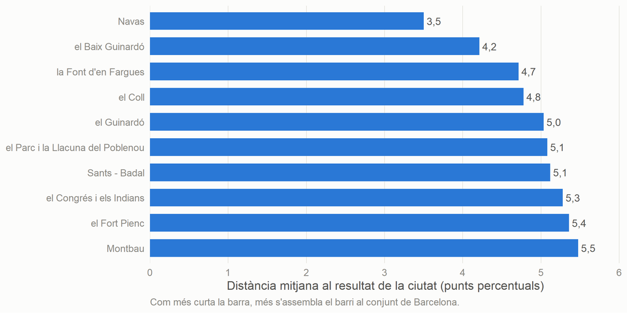

Figura 1: Els deu barris que, de mitjana, més s’han assemblat al resultat de tota la ciutat (eleccions de 1999 a 2023).

```r
ohio$barri_overall |>
  slice_head(n = 10) |>
  mutate(barri = forcats::fct_reorder(barri, mean_distance, .desc = TRUE)) |>
  ggplot(aes(x = 100 * mean_distance, y = barri)) +
  geom_col(fill = blue, width = 0.7) +
  geom_text(
    aes(label = formatC(100 * mean_distance, format = "f", digits = 1, decimal.mark = ",")),
    hjust = -0.2, colour = ink_2, size = 3.3
  ) +
  scale_x_continuous(expand = expansion(mult = c(0, 0.1))) +
  labs(
    x = "Distància mitjana al resultat de la ciutat (punts percentuals)",
    y = NULL,
    caption = "Com més curta la barra, més s'assembla el barri al conjunt de Barcelona."
  ) +
  theme_ohio() +
  theme(panel.grid.major.y = element_blank())
```

Si hi ha un barri que mereix el títol d’**Ohio de Barcelona**, és **Navas** (Sant Andreu). De mitjana, entre 1999 i 2023 el seu resultat s’ha allunyat només 3,5 punts percentuals del de la ciutat, i en cap de les set eleccions no ha superat els 4,2 punts. I sobretot, ho ha estat **de manera constant**: a totes les eleccions ha quedat entre els 4 barris més representatius dels 73 (posicions: 1999, 3a; 2003, 2a; 2007, 1a; 2011, 2a; 2015, 1a; 2019, 4a; 2023, 2a). A l’altre extrem, el barri menys representatiu és Pedralbes, a 32,5 punts de distància mitjana.

El resultat no depèn de la reconstrucció amb mapes: si fem la classificació només amb els barris oficials (2011–2023), Navas també és el primer, i les dues classificacions són gairebé idèntiques (correlació de rangs de 0,98).

El mapa mostra tots els barris ordenats de més a menys semblants a la ciutat. Cada color agrupa una cinquena part dels barris: en blau fosc, els 15 barris que més s’assemblen al conjunt de Barcelona; en vermell fosc, els que menys; i en gris, els del mig de la classificació.

**Mostra el codi**

```r
barris_ohio <- barris_map |>
  left_join(
    select(ohio$barri_overall, barri_code, mean_distance, rank, district),
    by = "barri_code"
  ) |>
  mutate(classe = distance_classes(mean_distance))

map_barris <- ohio_map(barris_ohio, highlight = filter(barris_ohio, barri_code == top_barri$barri_code)) +
  geom_sf_label(
    data = filter(barris_ohio, barri_code == top_barri$barri_code),
    aes(label = barri),
    nudge_x = 900, nudge_y = 900, size = 3.3, colour = ink,
    fill = "#fcfcfb", linewidth = 0, label.padding = unit(0.15, "lines")
  )

invisible(save_map(map_barris, "mapa_ohio_barris.png"))

ohio_leaflet(
  barris_ohio,
  labels = with(barris_ohio, paste0(
    bold(barri), "<br>", esc(district),
    "<br>Distància mitjana a la ciutat: ", pp(mean_distance),
    "<br>Posició: ", rank, " de ", n_barris
  )),
  legend_title = "Distància mitjana a la ciutat<br>(punts percentuals)",
  highlight = filter(barris_ohio, barri_code == top_barri$barri_code)
)
```

[interactive chart not shown]

Figura 2: Distància mitjana de cada barri al resultat de tota la ciutat (eleccions de 1999 a 2023), en cinquenes parts: en blau, els més semblants; en vermell, els més diferents. Contorn negre: l’Ohio de Barcelona. Línies fosques: límits de districte. Passeu el ratolí per sobre d’un barri per veure’n les dades.

**Mostra el codi**

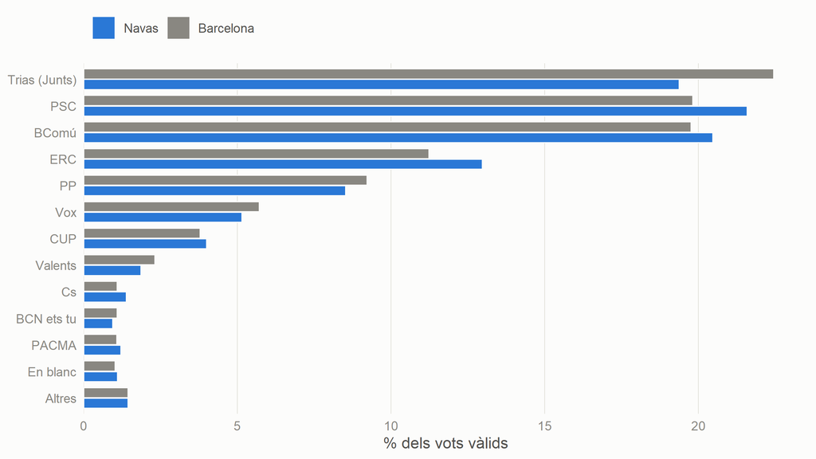

Figura 3: Resultat del barri més representatiu i de tota la ciutat a les eleccions de 2023. Les opcions amb menys d’un 1 % a la ciutat s’agrupen a «Altres».

```r
latest <- max(barri_elections)
labels_2023 <- c(
  "TriasxBCN" = "Trias (Junts)", "PSC-CP" = "PSC", "BCOMU-C" = "BComú",
  "ERC-AM" = "ERC", "PP" = "PP", "VOX" = "Vox", "CUP-AMUNT" = "CUP",
  "VALENTS" = "Valents", "Cs" = "Cs", "BCNETSTU" = "BCN ets tu",
  "PACMA" = "PACMA", "Vots blancs" = "En blanc"
)

main_fields <- ohio$city |>
  filter(date == latest, share >= 0.01) |>
  arrange(desc(share)) |>
  pull(field)

barri_shares <- elections |>
  filter(date == latest, barri_code == top_barri$barri_code) |>
  vote_shares()

bind_rows(
  mutate(filter(ohio$city, date == latest), lloc = "Barcelona"),
  mutate(barri_shares, lloc = top_barri$barri)
) |>
  mutate(field = if_else(field %in% main_fields, field, "Altres")) |>
  summarise(share = sum(share), .by = c(lloc, field)) |>
  mutate(
    field = factor(field, levels = rev(c(main_fields, "Altres"))),
    field = forcats::fct_relabel(field, \(x) dplyr::coalesce(labels_2023[x], x)),
    lloc = factor(lloc, levels = c(top_barri$barri, "Barcelona"))
  ) |>
  ggplot(aes(x = 100 * share, y = field, fill = lloc)) +
  geom_col(position = position_dodge(width = 0.8), width = 0.75, colour = "#fcfcfb", linewidth = 0.4) +
  scale_fill_manual(values = setNames(c(blue, muted), c(top_barri$barri, "Barcelona")), breaks = c(top_barri$barri, "Barcelona")) +
  scale_x_continuous(expand = expansion(mult = c(0, 0.05))) +
  labs(x = "% dels vots vàlids", y = NULL, fill = NULL) +
  theme_ohio() +
  theme(panel.grid.major.y = element_blank())
```

## 4.2 I a escala de secció censal?

**Mostra el codi**

```r
ohio$section_overall |>
  slice_head(n = 10) |>
  transmute(
    `#` = rank,
    Districte = district,
    Secció = section,
    Barri = barri,
    `Distància mitjana (pp)` = formatC(100 * mean_distance, format = "f", digits = 1, decimal.mark = ","),
    `Posició mitjana` = formatC(mean_rank, format = "f", digits = 1, decimal.mark = ",")
  ) |>
  kable(align = "rllrrr")
```

Taula 3: Les deu seccions censals més representatives de la ciutat de mitjana (eleccions de 2011 a 2023).

| # | Districte | Secció | Barri | Distància mitjana (pp) | Posició mitjana |
| --- | --- | --- | --- | --- | --- |
| 1 | Eixample | 9 | el Fort Pienc | 3,4 | 12,0 |
| 2 | Horta-Guinardó | 13 | el Baix Guinardó | 3,5 | 14,5 |
| 3 | Sants-Montjuïc | 81 | Sants - Badal | 3,6 | 16,0 |
| 4 | Sant Andreu | 94 | Navas | 3,8 | 17,5 |
| 5 | Sant Martí | 51 | la Vila Olímpica del Poblenou | 3,9 | 22,8 |
| 6 | Sant Andreu | 79 | el Congrés i els Indians | 4,0 | 36,2 |
| 7 | Sants-Montjuïc | 84 | Sants - Badal | 4,4 | 33,8 |
| 8 | Eixample | 128 | la Nova Esquerra de l’Eixample | 4,5 | 35,2 |
| 9 | Horta-Guinardó | 4 | el Baix Guinardó | 4,5 | 40,5 |
| 10 | Sants-Montjuïc | 85 | Sants - Badal | 4,5 | 38,2 |

La secció censal que més s’ha assemblat a la ciutat entre 2011 i 2023 és la **secció 9** (districte: Eixample; barri: **el Fort Pienc**), amb una distància mitjana de 3,4 punts. De mitjana, ha quedat en la posició 12,0 de 1.058 seccions comparables.

**Mostra el codi**

```r
# District and barri names of every current section (2023 election)
section_names <- ohio$section_distances |>
  filter(date == max(date)) |>
  distinct(district_code, section, district, barri)

sections_ohio <- sections_map |>
  left_join(section_names, by = c("district_code", "section")) |>
  left_join(
    select(ohio$section_overall, district_code, section, mean_distance, rank),
    by = c("district_code", "section")
  ) |>
  mutate(classe = distance_classes(mean_distance))

top_section_map <- filter(sections_ohio, district_code == top_section$district_code, section == top_section$section)

anchor <- sf::st_coordinates(sf::st_point_on_surface(sf::st_geometry(top_section_map)))
label_at <- anchor + c(-1800, -700)

map_sections <- ohio_map(sections_ohio, highlight = top_section_map, unit_lwd = 0.05) +
  annotate(
    "segment", x = label_at[1] + 600, y = label_at[2] + 120, xend = anchor[1], yend = anchor[2],
    colour = ink, linewidth = 0.4
  ) +
  annotate(
    "label", x = label_at[1], y = label_at[2],
    label = paste0("Secció ", top_section$section, " (", top_section$barri, ")"),
    size = 3.3, colour = ink, fill = "#fcfcfb", linewidth = 0, label.padding = unit(0.15, "lines")
  )

invisible(save_map(map_sections, "mapa_ohio_seccions.png"))

section_title <- \(units) with(units, paste0(
  bold(paste0("Secció ", section, " · ", district)), "<br>", esc(barri)
))

ohio_leaflet(
  sections_ohio,
  labels = paste0(
    section_title(sections_ohio),
    if_else(
      is.na(sections_ohio$mean_distance),
      "<br>Sense dades: la secció no existeix a totes quatre eleccions",
      paste0(
        "<br>Distància mitjana a la ciutat: ", pp(sections_ohio$mean_distance),
        "<br>Posició: ", sections_ohio$rank, " de ", num(n_sections)
      )
    )
  ),
  legend_title = "Distància mitjana a la ciutat<br>(punts percentuals)",
  highlight = top_section_map
)
```

[interactive chart not shown]

Figura 4: Distància mitjana de cada secció censal al resultat de tota la ciutat (eleccions de 2011 a 2023), en cinquenes parts: en blau, les més semblants; en vermell, les més diferents. Contorn negre: la secció més representativa. En gris fosc, les seccions que no existeixen a totes quatre eleccions. Passeu el ratolí per sobre d’una secció per veure’n les dades.

A escala de secció, el mapa és més granulat, però dibuixa el mateix patró que el dels barris.

Fixeu-vos que diversos noms es repeteixen a les dues escales: barris com Navas, el Baix Guinardó, Sants - Badal, el Congrés i els Indians, el Fort Pienc apareixen alhora entre els deu barris més representatius i entre les deu seccions més representatives. Aquesta coincidència suggereix que no és només casualitat.

## 4.3 L’Ohio de cada elecció

**Mostra el codi**

```r
ohio$barri_winners |>
  transmute(
    Elecció = any_of_date(date),
    Barri = barri,
    Districte = district,
    `Distància (pp)` = formatC(100 * distance, format = "f", digits = 1, decimal.mark = ","),
    `Barris de` = if_else(barri_source == "official", "dades oficials", "mapes INE")
  ) |>
  kable(align = "lllrl")
```

Taula 4: Barri més representatiu de la ciutat a cada elecció. Abans del 2011, el barri s’ha reconstruït amb els mapes de l’INE.

| Elecció | Barri | Districte | Distància (pp) | Barris de |
| --- | --- | --- | --- | --- |
| 1999 | el Poble-sec | Sants-Montjuïc | 2,4 | mapes INE |
| 2003 | el Congrés i els Indians | Sant Andreu | 2,6 | mapes INE |
| 2007 | Navas | Sant Andreu | 3,8 | mapes INE |
| 2011 | la Font d’en Fargues | Horta-Guinardó | 3,2 | dades oficials |
| 2015 | Navas | Sant Andreu | 3,0 | dades oficials |
| 2019 | el Fort Pienc | Eixample | 3,4 | dades oficials |
| 2023 | Can Baró | Horta-Guinardó | 4,1 | dades oficials |

**Mostra el codi**

```r
ohio$section_winners |>
  transmute(
    Elecció = any_of_date(date),
    Districte = district,
    Secció = section,
    Barri = coalesce(barri, "—"),
    `Vots vàlids` = num(valid),
    `Distància (pp)` = formatC(100 * distance, format = "f", digits = 1, decimal.mark = ","),
    `Seccions comparades` = num(n_units)
  ) |>
  kable(align = "llrlrrr")
```

Taula 5: Secció censal més representativa de la ciutat a cada elecció. Per a 1999–2007, el barri s’ha reconstruït amb els mapes de l’INE; per a 1987–1995 no es pot saber.

| Elecció | Districte | Secció | Barri | Vots vàlids | Distància (pp) | Seccions comparades |
| --- | --- | --- | --- | --- | --- | --- |
| 1987 | Horta-Guinardó | 179 | — | 425 | 1,7 | 1.917 |
| 1991 | Horta-Guinardó | 147 | — | 425 | 1,5 | 1.812 |
| 1995 | Sant Andreu | 41 | — | 529 | 1,0 | 1.582 |
| 1999 | Les Corts | 18 | la Maternitat i Sant Ramon | 634 | 2,0 | 1.488 |
| 2003 | Eixample | 82 | la Nova Esquerra de l’Eixample | 556 | 1,7 | 1.484 |
| 2007 | Sants-Montjuïc | 209 | Sants - Badal | 435 | 2,4 | 1.482 |
| 2011 | Eixample | 44 | la Sagrada Família | 498 | 2,3 | 1.061 |
| 2015 | Eixample | 9 | el Fort Pienc | 795 | 2,5 | 1.068 |
| 2019 | Sants-Montjuïc | 46 | la Font de la Guatlla | 784 | 1,7 | 1.068 |
| 2023 | Eixample | 131 | la Nova Esquerra de l’Eixample | 487 | 2,4 | 1.068 |

L’Ohio canvia gairebé a cada elecció. Això és normal: amb més de mil seccions, sempre n’hi ha alguna que, per pura combinació de circumstàncies, clava el resultat de la ciutat un any concret. El gràfic següent compara la secció més semblant de cada elecció amb la secció *típica* (la mediana).

**Mostra el codi**

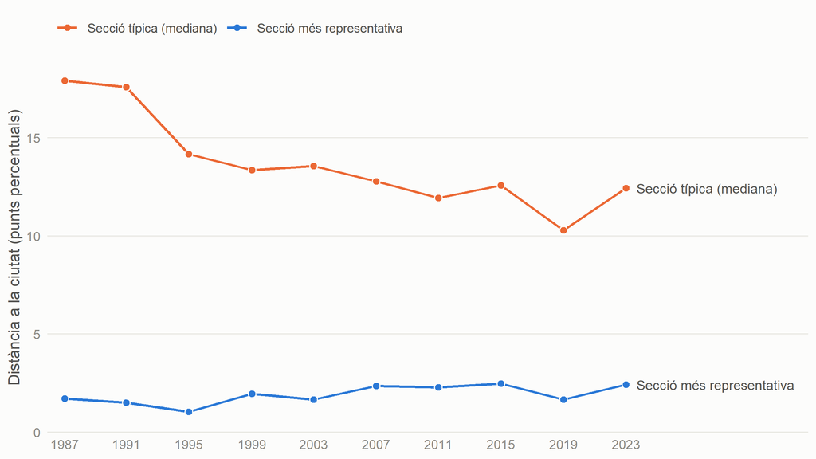

Figura 5: Distància al resultat de la ciutat de la secció més representativa i de la secció típica (mediana), a cada elecció.

```r
over_time <- ohio$section_distances |>
  summarise(
    `Secció més representativa` = min(distance),
    `Secció típica (mediana)` = median(distance),
    .by = date
  ) |>
  tidyr::pivot_longer(-date, names_to = "serie", values_to = "distance") |>
  mutate(serie = factor(serie, levels = c("Secció típica (mediana)", "Secció més representativa")))

ggplot(over_time, aes(x = date, y = 100 * distance, colour = serie)) +
  geom_line(linewidth = 0.8) +
  geom_point(size = 2.5, colour = "#fcfcfb", fill = NA) +
  geom_point(size = 1.8) +
  geom_text(
    data = filter(over_time, date == max(date)),
    aes(label = serie), hjust = 0, nudge_x = 250, size = 3.3, colour = ink_2, show.legend = FALSE
  ) +
  scale_colour_manual(values = c("Secció més representativa" = blue, "Secció típica (mediana)" = orange)) +
  scale_x_date(
    breaks = section_elections, labels = any_of_date,
    expand = expansion(mult = c(0.03, 0.3))
  ) +
  scale_y_continuous(limits = c(0, NA), expand = expansion(mult = c(0, 0.05))) +
  labs(x = NULL, y = "Distància a la ciutat (punts percentuals)", colour = NULL) +
  theme_ohio() +
  theme(panel.grid.major.x = element_blank())
```

La secció típica s’allunya de la ciutat entre 10,3 punts i 17,9 punts, mentre que la més representativa de cada any no passa mai dels 2,5 punts.

# 5 Una altra mirada: l’Ohio del guanyador

L’Ohio dels Estats Units era famós per una cosa molt concreta: **votava el guanyador**. Fins ara hem buscat una cosa més exigent, que un lloc repeteixi el repartiment de vots de tota la ciutat. Però també podem fer-nos la pregunta clàssica: **hi ha barris on sempre guanya el mateix partit que guanya a Barcelona?**

La regla és senzilla: per a cada elecció, mirem quin partit ha tret més vots a la ciutat i quin n’ha tret més a cada barri o secció. Si coincideixen, el lloc «encerta» el guanyador. Els vots en blanc no poden guanyar, i un empat al primer lloc compta com a no encert.

**Mostra el codi**

```r
ohio$city_winners |>
  left_join(
    summarise(ohio$barri_winner_matches, barris = sum(match), .by = date),
    by = "date"
  ) |>
  left_join(
    summarise(ohio$section_winner_matches, seccions = mean(match), .by = date),
    by = "date"
  ) |>
  transmute(
    Elecció = any_of_date(date),
    Guanyador = party(winner),
    `% vàlids` = formatC(100 * winner_share, format = "f", digits = 1, decimal.mark = ","),
    `Avantatge sobre el segon (pp)` = formatC(100 * margin, format = "f", digits = 1, decimal.mark = ","),
    `Barris on guanya` = if_else(is.na(barris), "—", paste(barris, "de", n_barris)),
    `% de seccions on guanya` = pct(seccions)
  ) |>
  kable(align = "llrrrr")
```

Taula 6: Partit més votat a tota la ciutat a cada elecció, i quants barris i seccions el van votar també com a primera força.

| Elecció | Guanyador | % vàlids | Avantatge sobre el segon (pp) | Barris on guanya | % de seccions on guanya |
| --- | --- | --- | --- | --- | --- |
| 1987 | PSC | 43,6 | 8,2 | — | 59,2 % |
| 1991 | PSC | 43,0 | 8,9 | — | 58,8 % |
| 1995 | PSC | 38,3 | 7,8 | — | 58,0 % |
| 1999 | PSC | 45,1 | 23,4 | 66 de 73 | 84,2 % |
| 2003 | PSC | 33,6 | 12,2 | 59 de 73 | 71,4 % |
| 2007 | PSC | 29,9 | 4,5 | 55 de 73 | 60,6 % |
| 2011 | CiU | 28,7 | 6,6 | 36 de 73 | 60,0 % |
| 2015 | Barcelona en Comú | 25,2 | 2,5 | 54 de 73 | 62,4 % |
| 2019 | ERC | 21,4 | 0,6 | 29 de 73 | 41,3 % |
| 2023 | Trias per Barcelona (Junts) | 22,5 | 2,6 | 21 de 73 | 38,0 % |

Com més ajustada és l’elecció, més difícil és encertar-la. El 2019, ERC va guanyar la ciutat per només 0,6 punts percentuals, i el 2023 Trias per Barcelona ho va fer amb poc més del 22 % dels vots: només 21 dels 73 barris el van tenir com a primera força.

## 5.1 Els barris que sempre encerten

**Mostra el codi**

```r
always_barris |>
  transmute(
    Barri = barri,
    Districte = district,
    Encerts = paste(n_matches, "de", n_elections),
    `Posició per distància` = paste0(distance_rank, "a de ", n_barris)
  ) |>
  kable(align = "llrr")
```

Taula 7: Barris on el partit més votat ha coincidit amb el de tota la ciutat a totes les eleccions de 1999 a 2023, i la seva posició a la classificació per distància.

| Barri | Districte | Encerts | Posició per distància |
| --- | --- | --- | --- |
| el Baix Guinardó | Horta-Guinardó | 7 de 7 | 2a de 73 |
| la Font d’en Fargues | Horta-Guinardó | 7 de 7 | 3a de 73 |
| la Vila Olímpica del Poblenou | Sant Martí | 7 de 7 | 12a de 73 |

Només **tres barris** han votat el mateix guanyador que la ciutat a totes les set eleccions de 1999 a 2023: **el Baix Guinardó**, **la Font d’en Fargues** i **la Vila Olímpica del Poblenou**. Si fem el càlcul només amb els barris oficials (2011–2023), en surten exactament els mateixos.

I Navas, l’Ohio per distància? Ha encertat el guanyador 6 de 7 vegades. L’única que va fallar és el 2023, quan el partit més votat a Navas va ser el PSC i a la ciutat, Trias per Barcelona (Junts). És un bon exemple de la diferència entre els dos criteris: el criteri del guanyador és de tot o res i depèn de quin partit queda primer per pocs vots, mentre que la distància té en compte com es reparteixen els vots entre tots els partits.

**Mostra el codi**

```r
# One line per election for the tooltips: "2023: PSC ✗"
winner_history <- function(matches, by) {
  matches |>
    arrange(date) |>
    mutate(line = paste0(
      any_of_date(date), ": ", esc(coalesce(party(winner), "empat")),
      if_else(match, " ✓", " ✗")
    )) |>
    summarise(history = paste(line, collapse = "<br>"), .by = all_of(by))
}

barris_winner <- barris_map |>
  left_join(select(barri_record, barri_code, n_matches, n_elections, district), by = "barri_code") |>
  left_join(winner_history(ohio$barri_winner_matches, "barri_code"), by = "barri_code") |>
  mutate(classe = match_classes(n_matches, total = n_barri_winner_elections, floor = 3))

map_winner_barris <- ohio_map(
  barris_winner,
  highlight = filter(barris_winner, barri_code %in% always_barris$barri_code),
  palette = match_fill,
  legend_title = "Eleccions en què el barri\nva votar el guanyador de la ciutat"
)

invisible(save_map(map_winner_barris, "mapa_guanyador_barris.png"))

ohio_leaflet(
  barris_winner,
  labels = with(barris_winner, paste0(
    bold(barri), "<br>", esc(district),
    "<br>Encerts: ", n_matches, " de ", n_elections,
    "<br><br>Partit més votat al barri<br>(✓ = el mateix que a la ciutat):<br>", history
  )),
  palette = match_fill,
  legend_title = "Eleccions en què el barri<br>va votar el guanyador de la ciutat",
  highlight = filter(barris_winner, barri_code %in% always_barris$barri_code)
)
```

[interactive chart not shown]

Figura 6: Nombre d’eleccions (de 1999 a 2023) en què el partit més votat al barri ha coincidit amb el de tota la ciutat. Contorn negre: els barris que sempre han encertat. Passeu el ratolí per sobre d’un barri per veure qui hi va guanyar a cada elecció.

## 5.2 I les seccions censals?

A escala de secció, i per al període 2011–2023, 29 de les 1.058 seccions (un 2,7 %) han votat sempre el mateix guanyador que la ciutat. On són? Sobretot a la Sagrada Família (5), el Baix Guinardó (3) i el Parc i la Llacuna del Poblenou (3).

**Mostra el codi**

```r
section_keys <- c("district_code", "section")
n_section_winner_elections <- max(section_record$n_elections)

sections_winner <- sections_map |>
  left_join(section_names, by = section_keys) |>
  left_join(select(section_record, all_of(section_keys), n_matches), by = section_keys) |>
  left_join(
    winner_history(filter(ohio$section_winner_matches, date >= as.Date("2011-01-01")), section_keys),
    by = section_keys
  ) |>
  mutate(classe = match_classes(n_matches, total = n_section_winner_elections))

map_winner_sections <- ohio_map(
  sections_winner,
  unit_lwd = 0.05,
  palette = match_fill,
  legend_title = "Eleccions en què la secció\nva votar el guanyador de la ciutat"
)

invisible(save_map(map_winner_sections, "mapa_guanyador_seccions.png"))

ohio_leaflet(
  sections_winner,
  labels = paste0(
    section_title(sections_winner),
    if_else(
      is.na(sections_winner$n_matches),
      "<br>Sense dades: la secció no existeix a totes quatre eleccions",
      paste0(
        "<br>Encerts: ", sections_winner$n_matches, " de ", n_section_winner_elections,
        "<br><br>Partit més votat a la secció<br>(✓ = el mateix que a la ciutat):<br>",
        sections_winner$history
      )
    )
  ),
  palette = match_fill,
  legend_title = "Eleccions en què la secció<br>va votar el guanyador de la ciutat"
)
```

[interactive chart not shown]

Figura 7: Nombre d’eleccions (de 2011 a 2023) en què el partit més votat a la secció censal ha coincidit amb el de tota la ciutat. En gris, les seccions que no existeixen a totes quatre eleccions. Passeu el ratolí per sobre d’una secció per veure qui hi va guanyar a cada elecció.

Les dues maneres de buscar l’Ohio no donen exactament el mateix resultat, però s’assemblen: el Baix Guinardó i la Font d’en Fargues són alhora dels barris que sempre encerten el guanyador i dels deu més semblants a la ciutat per distància.

# 6 Limitacions i coses a tenir en compte

- **Seccions petites, soroll gran.** Una secció té al voltant d’un miler d’electors; un grapat de vots pot moure’n força els percentatges. Per això donem més pes a la classificació global, que fa la mitjana de quatre eleccions, que no pas al guanyador d’un any concret.
- **Els límits de les seccions canvien.** Entre 2011 i 2023 la divisió és força estable (d’unes 1.061 a 1.068 seccions), però no idèntica. Comparem les seccions pel seu codi, que és una bona aproximació, però no perfecta.
- **Barris reconstruïts.** Per a 1999–2007, cada secció s’assigna sencera al barri on té més superfície. Les poques seccions partides entre dos barris hi compten senceres, i els barris molt petits poden quedar representats per molt poques seccions. La comprovació del 2011 i el fet que la classificació gairebé no canviï indiquen que l’efecte és petit.
- **Representatiu del vot, no de la població.** Mesurem si un lloc *vota* com la ciutat, no si hi viu gent com la de la resta de la ciutat (edat, renda, origen…). És una pregunta diferent.
- **Tots els partits pesen igual.** La distància euclidiana tracta igual un punt de diferència en un partit gran i en un de petit. En la pràctica, però, les diferències grans solen venir dels partits grans, que són els que més determinen el resultat.
- **L’abstenció no hi compta.** Un lloc pot repartir el vot com la ciutat però tenir molta més o molta menys participació. Si s’hi volgués incloure, es podria afegir l’abstenció com una opció més, calculant els percentatges sobre el cens.
- **Dades d’origen.** A les dades de 1991 hi ha una secció (districte 10, secció 90) on la suma de vots a candidatures i en blanc supera en 2 els vots vàlids oficials. La diferència és negligible.

# 7 Reproduir l’anàlisi

Tot el codi és al projecte:

- `R/ohio.R`: funcions per llegir les dades, calcular percentatges, distàncies i classificacions.
- `R/geo.R`: funcions per llegir els mapes i situar les seccions als barris.
- `analysis/00_build_crosswalk.R`: superposa els mapes de l’INE als barris i en fa la validació amb el 2011. Cal executar-lo primer.
- `analysis/01_find_ohio.R`: executa l’anàlisi i desa les taules a `output/tables/` i `data/processed/`.
- `tests/testthat/`: proves de les funcions.
- Aquest document es pot regenerar amb `quarto render reports/ohio_barcelona.qmd`.